# Bruhn_C07_2

$$w = 1.90t \sqrt{E/F_{ST}} \quad
\text{---} \quad (C7.16)$$

Newellによるいくつかの初期の実験では、定数1.90は高すぎ、軽量なストリンガーに対しては1.7という値がより現実的であることが示され、そのため、航空業界では1.7が広く使用されている。

補強材（スチフナ）とその外板への取り付け部の剛性が、外板に対して固定またはクランプ端支持条件を構成すると仮定すると、

$$F_{cr} = 6.35E(t/b)^2 \quad
\text{または} \quad w = 2.52t \sqrt{E/F_{ST}}$$

一般的な設計目的には、有効幅 $w$ を決定するために1.9または式(C7.15)が適切であると考えられている。補強材が比較的軽い場合は、1.7を使用する。Fig. C7.14は、補強材の各フランジに対して単一の締結ラインによって結合された外板・補強材ユニットの有効幅を示している。

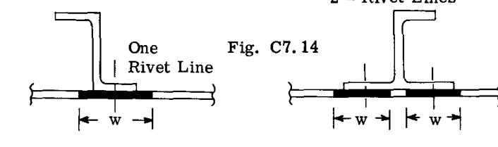

Fig. C7.14

クリップリング応力は補強材単体に対して決定される。この応力はその後、式(C7.15)において有効幅 $w$ を決定するために使用される。総面積は、補強材の面積に有効外板幅 $w$ の面積を加えたものに等しくなる。断面二次半径には、有効外板面積の影響を含める必要がある。

Fig. C7.15は、補強材が各補強材フランジ上で2列のリベットによって外板に締結されている場合を示している。この場合、リベットラインが非常に近いため、各リベットラインに対する有効幅 $w$ が大きく重なり合う。このような場合、航空業界での一般的な慣行は、各補強材フランジに伴う外板幅を表すために、式(C7.16)による1列のリベット取り付けに対する有効幅を使用することである。しかし、補強材単体のクリップリング応力を計算する際、外板に取り付けられている補強材フランジは、フランジ厚さと外板厚さの和の3/4に等しい厚さを持つとみなされる。

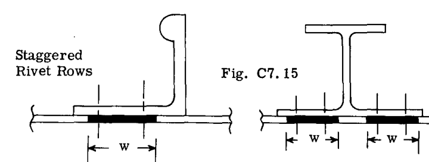

Fig. C7.15

式(C7.16)によって計算される有効外板幅は、外板の相互リベット座屈が発生しない、すなわち、外板が補強材のクリップリング応力を負担しているときに、リベット間の外板の局所座屈を防ぐのに十分な近さでリベットまたはスポット溶接が配置されていることを前提としている。リベット間の外板座屈の問題については、本章の後半で説明する。

Fig. C7.16は、製造において外板と補強材が一体となっている場合に、有効幅 $w$ を決定するための手順を示している。

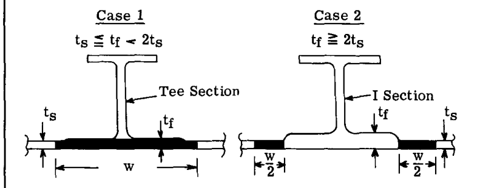

Fig. C7.16

ケース1については、T字断面の垂直なステムの両端が単純支持されていると仮定して、T字断面単体のクリップリング応力を求める。式(C7.15)における $t$ の値には、 $(t_s + t_f)/2$ を使用する。有効補強材面積は、T字の面積に幅 $w$ の外板の面積を加えたものに等しい。

ケース2については、I字断面が単独で作用する場合のクリップリング応力を決定する。有効外板面積に含めるために、式(C7.15)から $w/2$ を計算する。柱の特性には、I字断面に有効外板を加えたものを含める必要がある。

## C7.12 一方の縁が自由な外板の有効幅 $w_1$

通常の「外板・補強材」構造では、外板は通常、補強材の端部で終了するため、Fig. C7.16aに示すように外板の片縁自由条件が生じる。外板は、リベット線から距離 $b'$ の位置で終了する。片縁が自由な外板の場合、式(C7.13)における座屈係数は0.43であり、したがって式(C7.13)は以下のように簡略化される。

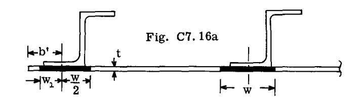

Fig. C7.16a

$$F_{cr} = .387E(t/b')^2$$

そして、 $b'$ を $w$ に置き換えることで、以下を得る。

$$w_1 = .62t \sqrt{E/F_{ST}} \quad
\text{---} \quad (C7.17)$$

したがって、この端部補強材に対する総有効外板幅は $w_1 + w/2$ に等しくなる。

## C7.13 外板と補強材が異なる材料特性を持つ場合の有効幅

$$w = 1.90t (F_{SH}/F_{ST})
\left(\sqrt{\frac{E}{F_{ST}}}\right) \quad \text{---} \quad
(C7.18)$$

ここで、 $f_{ST}$ は補強材応力であり、 $f_{SH}$ は補強材と同じひずみにおいて外板に存在する応力であり、外板材料の応力-ひずみ曲線から得られる。

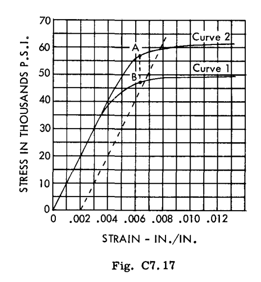

Fig. C7.17

様々な有効幅理論のかなり完全な調査と詳細な比較については、Gerardの論文(Ref. 7)を参照されたい。式(C7.15)は、 $b/t$ 比が高い場合には一般的に安全側（保守的）である。

## C7.14 リベット間座屈応力

有効な外板領域は、補強材と一体となって作用すると考えられている。しかし、外板を補強材に締結するリベットまたはスポット溶接の間隔が広すぎると、補強材のクリップリング応力に達する前に、リベット間で外板が座屈し、圧縮荷重を負担する際の補強材への寄与が低下する。したがって、一般に、構造重量を節約するために、構造設計者は外板のリベット間座屈を防ぐリベット間隔を選択する。一般に、主翼上面の設計圧縮荷重は下面の荷重よりもかなり大きいため、主翼の上面における補強材に沿ったリベット間隔は、下面よりも細かくなる。

以下の方法は、宇宙航空構造に関連するリベット間座屈応力の計算に関して、エンジニアの間で広く使用されている。隣接するリベット間の外板は、両端固定の柱として作用すると仮定される。

安定した断面に対する第C2章の一般的な柱の式は、

$$F_c = C \pi^2 E_t / (L/\rho)^2 \quad
\text{---} \quad (C7.19)$$

ここで、 $C$ は端部固定度係数であり、ピン支持支持の1から固定支持の4までの値をとる。

有効な柱の長さ $L' = L/\sqrt{C}$ とすると、式(C7.19)は次のように書くことができる。

$$F_c = \pi^2 E_t / (L'/\rho)^2 \quad
\text{---} \quad (C7.20)$$

リベット間隔 $p$ を柱の長さ $L$ とみなす。幅1インチ、厚さ $t$ の外板ユニットを仮定する。このとき、断面積の慣性モーメント $= 1 \times t^3 / 12$ 、面積 $A = 1 \times t = t$ となる。したがって、断面二次半径 $\rho = 0.29t$ である。これを式(C7.20)に代入して、リベット間座屈応力 $F_{ir}$ を得る。

$$F_{ir} = \frac{\pi^2
E_t}{\left(\frac{p}{\sqrt{C}} / 0.29t\right)^2} \quad \text{---} \quad
(C7.21)$$

クランプ端の場合、 $C = 4$ であるため、次のようになる。

$$F_{ir} = \frac{\pi^2 E_t}{(p / 0.58t)^2}
\quad \text{---} \quad (C7.22)$$

この式をプロットするには、材料の接線係数 $E_t$ を知る必要がある。しかし、第C2章の様々な柱の曲線（ $F_c$ 対 $L'/\rho$ のプロット）を使用することができ、式(C7.22)の $p/0.58t$ 項は $L'/\rho$ に対応する。

平頭リベットには固定度係数 $C = 4$ を使用できる。スポット溶接の場合は 3.5 に下げる必要がある。丸頭リベット（Brazier rivet）タイプの場合は $C = 3$ 、皿頭またはディンプルリベットの場合は $C = 1$ を使用する。

Figs. C7.18 と C7.19 は、アルミニウム合金材料に対する式(C7.22)のプロットを示している。

リベット間座屈応力の計算値が補強材のクリップリング応力よりも大きい場合、有効外板面積を補強材面積に加算して総有効面積を得ることができる。この総有効面積に補強材のクリップリング応力を乗じることで、総外板・補強材ユニットのクリップリング荷重が得られる。

リベット間の外板が補強材のクリップリング応力に達する前に座屈する場合、座屈状態の外板は、補強材がクリップリング応力に達するまで荷重を受け続ける間、この応力をほぼ維持する能力を持っている。この座屈外板強度は、有効外板面積を減少させることで利用できる。したがって、補正された有効外板幅は次のようになる。

$$w_{\text{corrected}} = w (F_{ir}/F_{cs})
\quad \text{---} \quad (C7.23)$$

補正された有効外板の面積が補強材の面積に加えられる。クリップリング荷重は、補強材のクリップリング応力に総面積を乗じたものに等しくなる。

主翼または胴体断面の断面二次モーメントを求める際に外板の有効幅を使用することは、従来の主翼および胴体構造における曲げ応力解析で広く使用されている手順である。有効幅の使用に関する実際の例については、第A19章のセクションA19.13および第A20章のセクションA20.3を参照されたい。

## C7.15 有効外板に関する例題

通常の航空機主翼構造を Fig. C7.20 に示す。主翼は通常外板と呼ばれる板で覆われており、この外板は、外板スチフナまたは外板ストリンガーと呼ばれる成形または押出形状を取り付けることによって補強されている。代表的な主翼断面は、1つまたは複数の内部の直線ウェブを含み、これらのウェブを外板に結合するために、しばしばウェブフランジ部材と呼ばれるストリンガーが、この接続を容易にするために必要となる。Fig. C7.21 はフランジ部材の詳細であり、Fig. C7.20 における点(1)での接続を示している。

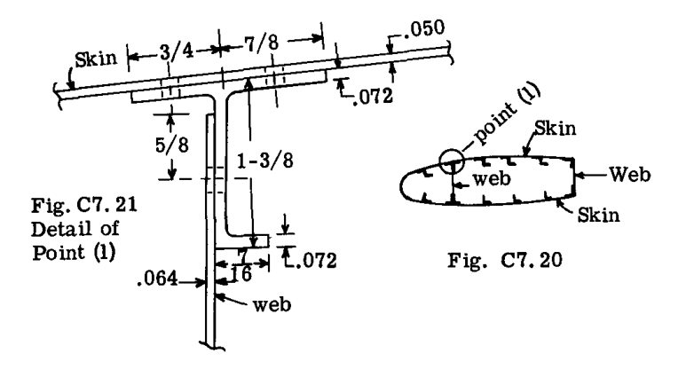

Fig. C7.21 / Fig. C7.20

補強材またはフランジ部材は、7075-T6アルミニウム合金の押出材である。外板およびウェブ板は7075-T6アルミニウム合金である。外板は、直径1/8インチの丸頭（Brazier head）リベット2列によって補強材に固定されており、リベット間隔は7/8インチである。ウェブは、直径3/16インチのリベット1列、間隔1インチで補強材に取り付けられている。問題は、補強材のクリップリング応力、有効外板面積、およびこのユニットが破壊点で負担できる総圧縮荷重を決定することである。補強材はウェブと外板によって横方向に支持されているため、柱の曲げ作用は防止され、したがってクリップリング強度は、縦方向の圧縮下におけるこのコーナー部材の真の強度となる。（ウェブがせん断応力下で座屈し、ウェブの斜め引張力が作用している場合、これらのコーナー部材には追加の応力が発生する。この主題は、半引張フィールドビームに関する章で扱われる。）

### 解答：

補強材の面積 $= 0.24 \text{ sq. in.}$ 7075-T6押出材に対して、 $F_{cy} = 70,000, \, E_c = 10,500,000$ psi.

クリップリング応力の計算にはGerardの方法を使用する。式(C7.4)またはFig. C7.7の設計曲線が、このマルチコーナー形状に適用される。Fig. C7.7の下部スケールパラメータは以下の通りである。

$$\frac{A}{gt^2}\left(\frac{F_{cy}}{E_c}\right)^{1/2}
= \frac{0.24}{6 \times 0.072^2}
\left(\frac{70,000}{10,500,000}\right)^{1/2} = 0.63$$

この値を用いて、Fig. C7.7から $F_{cs}/F_{cy} = 0.82$ を読み取る。したがって、 $F_{cs} = 0.82 \times 70,000 = 57,400$ psi である。 $g$ の値6は、Fig. a に示すように決定された。

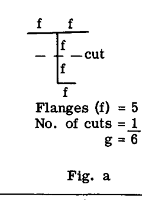

Fig. a

### 有効外板幅：

外板の有効幅を決定するために、式(C7.16)が使用される。

外板厚さ $t = 0.05$ に対して。 材料は7075-T6アルミニウム合金。 $E_c = 10,500,000$ psi.

$$w = 1.9t \sqrt{E/F_{cs}} = 1.9 \times
0.05 \sqrt{10,500,000 / 57,400} = 1.28 \text{ in.}$$

したがって、 $1.28 / 2 = 0.64$ 幅の外板がリベット中心線の両側に作用する。Fig. C7.21の寸法を観察すると、各外板リベット列における有効幅はわずかに重なり合うため、リベット列間の幅のみを使用する（Fig. b を参照）。

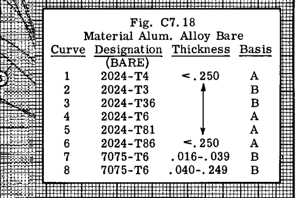

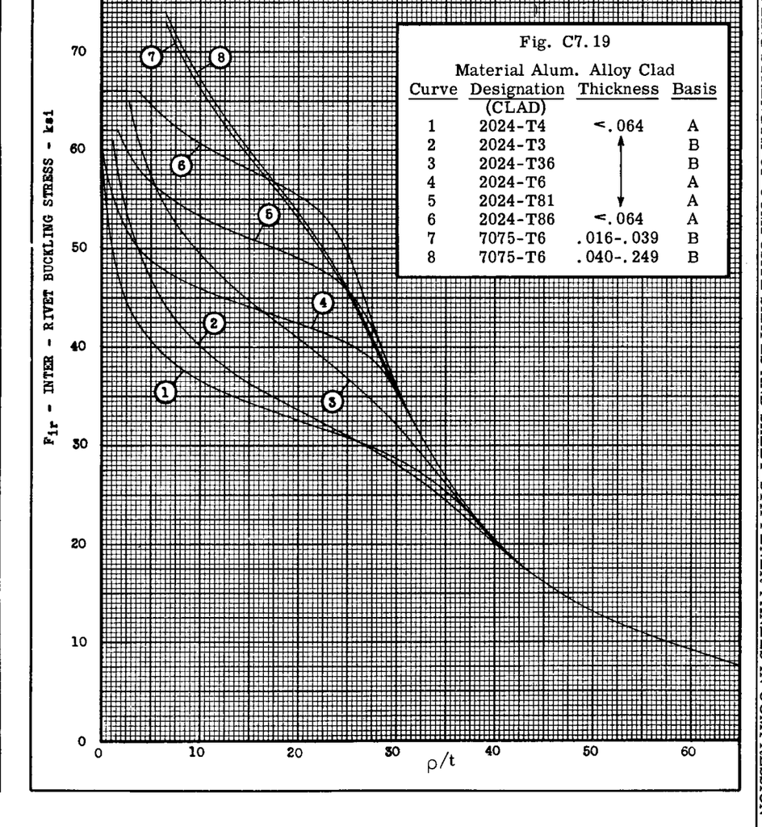

ウェブ厚さ $t = 0.064$ について。ウェブは一方の縁が自由であるため、有効幅の計算は2つのステップで行われる。

$$\frac{w}{2} = \frac{1.9}{2} \times 0.064
\sqrt{10,500,000/57,400} = 0.82 \text{ in.}$$

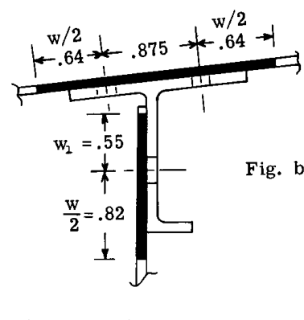

Fig. b

Fig. b は、計算された有効外板幅を示している。 総有効外板面積
$$= 1.28 \times 0.05 + 0.875 \times 0.05 + (0.55 +
0.82) \times 0.064 = 0.195$$
総面積
$$= 0.195 + 0.24 = 0.435 \text{ sq.
in.}$$

破壊前にユニット全体が負担できる総圧縮荷重は、次のようになる。
$$P = A F_{cs} = 0.435 \times 57,400 = 25,000
\text{ lbs.}$$

この結果は、リベット間の外板において 57,400 psi の応力下でリベット間座屈が発生しないことを前提としている。

外板リベットは丸頭（Brazier head）タイプで、間隔は 7/8 インチ、すなわち $p = 7/8$ である。

リベット間座屈の項目で議論したように、このタイプのリベットに対する端部固定度係数 $C$ は 4 未満である必要があり、ここでは 3 と仮定する。

Fig. C7.18 は、 $p/t$ 比に対するリベット間座屈応力を示している。このチャートは、両端固定条件または $C = 4$ に基づいている。丸頭リベットに対しては $C = 3$ が使用されるため、 $p/t$ 比を $\sqrt{4}/\sqrt{3} = 1.16$ の比率で補正する。

補正された $p/t = 1.16 \times 0.875 / 0.05 = 20.3$

対象材料の曲線(8)を使用して Fig. C7.18 から、 $F_{ir} = 60,000$ psi を読み取る。したがって、外板のクリップリング応力が 57,400 psi であるため、リベット間で外板が座屈することはない。

ウェブのリベットは平頭（flat head）タイプであり、 $C = 4$ を使用できる。間隔は 1 インチである。 したがって、 $p/t = 1 / 0.064 = 15.6$ となり、Fig. C7.18 の曲線8から $F_{ir} = 64,600$ psi を読み取る。これは、ユニットのクリップリング応力よりもかなり高い。

主翼構造において、外板リベットは通常、皿頭（countersunk）またはディンプル（dimpled）のいずれかのフラッシュ（平滑）表面タイプである。外板リベットを皿頭タイプにする場合、安全のために端部固定度係数を 1 に下げる必要がある。このとき、 Fig. C7.18 で使用する補正された $p/t$ 比は、 $(\sqrt{4}/\sqrt{1}) p/t = 2 \times 0.875 / 0.05 = 35$ となる。Fig. C7.18 および曲線8から、 $F_{ir} = 29,000$ psi となり、これは計算されたクリップリング応力を大きく下回る。したがって、リベット間隔を狭める必要がある。9/16 インチの間隔を使用すると、補正された $p/t = 2 \times 0.5625 / 0.05 = 22.5$ となる。 Fig. C7.18 から、 $F_{ir} = 57,400$ psi となり、これはクリップリング応力と一致するため、満足のいく結果となる。

## C7.16 短い外板・補強材パネルの圧縮破壊強度

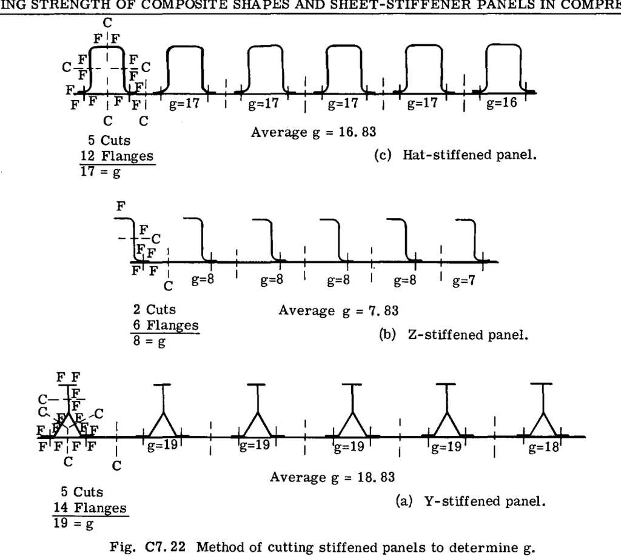

[figure not shown]

## C7.17 リンクリングによる破壊

Howland (Ref. 8) は、外板が両端でクランプされ、その長さがリベット間隔に等しい幅広の柱として作用すると仮定した。このときのリベット間座屈応力の式は以下の通りである。

$$F_{ir} = \frac{C \pi^2 \eta
\bar{\eta}}{12(1 -
u_e^2)} \left(\frac{t_s}{p}\right)^2 \quad \text{---} \quad
(C7.24)$$

端部固定度係数 $C$ は、平頭リベットに対しては 4 とし、他のタイプに対しては前述の式(C7.21)と同様に減少させる。

$\eta$ は塑性補正係数 $\bar{\eta}$ はクラッド補正係数 $u_e$ はポアソン比（0.30を使用） $t_s$ は外板厚さ（インチ） $p$ はリベット間隔またはピッチ（インチ）

## C7.18 外板のシワ寄り（リンクリング）による短いパネルの破壊

リベット締結された外板・補強材パネルにおいて、リベット間隔が比較的大きい場合、外板はリベット間で座屈する（Fig. C7.25の写真に示すように）。このリベット間座屈応力については、前項で説明した。

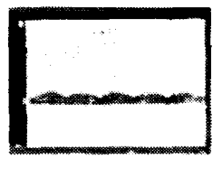

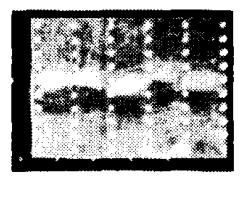

しかし、リベットまたはスポット溶接の間隔が外板のリベット間座屈を防ぐようなものである場合、破壊はしばしばFig. C7.26に示すような、より大きな外板のシワ寄り（リンクリング）によって発生する。このより大きなシワの形状は、外板が取り付けられている補強材のフランジに横方向の力を及ぼし、その結果、補強材フランジは外板のシワ形状とともに変形することが多い。この補強材フランジの変形は補強材ウェブに応力を発生させるため、リンクリング破壊は外板と補強材の共同破壊となる。補強材フランジを変形させる外板のシワの作用は、リベットに引張荷重をかけるため、リベットの設計が圧縮下における外板・補強材パネルの破壊強度に関与することになる。

いくつかの研究者がこのシワ寄り、またはリベット留めパネルの強制クリップリングについて研究を行っている (Refs. 9, 10)。最近の研究は Semonian と Peterson (Ref. 11) によって行われ、これは Gerard (Ref. 2) によってある程度レビューおよび簡略化されている。 (Refs. 11, 2) に示されている結果は、リンクリング応力を計算するために使用される。

### C7.19 リンクリング破壊応力 $F_w$ の式

Ref. 2 より、次式を得る。

$$F_w = \frac{k_w \pi^2 \eta \bar{\eta}
E}{12(1 -
u_e^2)} \left(\frac{t_s}{b_s}\right)^2 \quad \text{---} \quad
(C7.25)$$

### C7.20 リンクリング破壊に対するリベット基準

試験データから得られた、リンクリングモード破壊をもたらすリベットピッチの基準は、以下の通りである。

$$p/b_s \le 1.27 / k_w^{1/2} \quad
\text{---} \quad (C7.26)$$

ストリンガー取付フランジを波打った外板に追従させるために必要な横力は、リベットに引張荷重をかける。 Ref. 2 によるリベット強度の近似基準は、以下の通りである。

$$S_r \ge \frac{0.7 b_s}{E_{ST}}
\frac{p}{d} \frac{d}{d} (F_w)^2 \quad \text{---} \quad
(C7.27)$$

リベットの引張強度 $S_r$ はシャンク断面積に基づいて定義され、これはシャンクの破壊、または皿頭リベットが外板を通り抜けて抜けることのいずれかに関連している可能性がある。

引張強度が $s = 57$ ksi であるアルミニウム合金 2117-T4 リベットについて、基準は以下の通りである。

$$\left. \begin{aligned} s &= 57
\text{ ksi}, \quad d_e/t_{av} \le 1.67 \\ s &=
\frac{190}{d_e/t_{av}} - \frac{160}{(d_e/t_{av})^2}, \quad d_e/t_{av}
> 1.67 \end{aligned} \right\} \quad \text{---} \quad
(C7.28)$$

ここで、 $t_{av}$ は外板と補強材の平均厚さ（インチ）である。有効径 $d_e$ は、2117-T4材料で作られたリベットの直径である。

別の材料のリベットの有効径は、以下の通りである。

$$d_e/d = (S_r / s)^{1/2} \quad \text{---}
\quad (C7.29)$$

ここで、 $S_r$ は、シャンク断面積で割った最大引張荷重として定義される、リベットの引張強度（ksi単位）である。

### C7.21 例題 1. 短いパネルの破壊強度の計算例

Fig. C7.29 は、成形されたZ形補強材から構成される外板・補強材パネルを示している。材料はアルミニウム合金 2024-T3 である。 $F_{cy} = 40,000$ psi、 $F_{0.7} = 39,000$ psi、 $n = 11.5$ 、 $E_c = 10,700,000$ psi。問題は、このパネルユニットの短い長さにおける圧縮破壊強度を決定することである。

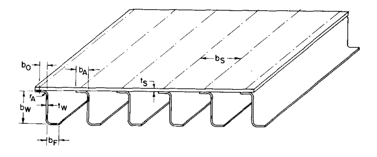

Fig. C7.29

#### 一般的なパネルデータ：

- $t_w = 0.064$
- $t_s = 0.064$
- $b_w = 2.437$
- $b_f = 0.905$
- $b_A = 0.593$
- $b_o = 0.343$
- $b_s = 2.00$

したがって、 $b_w/t_w = 38$ 、 $b_f/b_w = 0.372$ 、 $b_A/t_w = 9.27$ 、 $b_o/t_w = 5.36$ である。

リベットは、直径 3/32 インチの丸頭（Brazier head）タイプ AN456、2117-T3 材料で、間隔は 0.75 インチである。

- Z形補強材の面積 $= 0.252 \text{ in.}^2$
- $b_s = 2$ インチに対する外板の面積 $= 2 \times 0.064 = 0.128 \text{ in.}^2$
- 外板と補強材の総面積 $= 0.380 \text{ in.}^2$

#### 補強材単独で作用する場合のクリップリング応力 $F_{cs(ST)}$

Fig. C7.9より、 $F_{cs}/F_{cy} = 0.6$ 。したがって、 $F_{cs} = 0.6 \times 40,000 = 24,000 \text{ psi} = F_{cs(ST)}$ となる。

#### モノリシック限界として考慮されるパネルのクリップリング応力 $F_{cs(M)}$

外板・補強材パネルのモノリシック破壊には、式(C7.4)またはFig. C7.7が適用される。 Fig. C7.7の下部スケールパラメータは以下の通りである。

$$\left(\frac{A}{gt_s^2}\right)
\left(\frac{F_{cy}}{E_c}\right)^{1/2} = \left(\frac{0.380}{7.83 \times
0.064^2}\right) \left(\frac{40,000}{10,700,000}\right)^{1/2} =
0.73$$

$g = 7.83$ （Fig. C7.22bを参照）。

Fig. C7.7より、 $F_{cs}/F_{cy} = 0.725$ 、したがって $F_{cs} = 40,000 \times 0.725 = 29,000 \text{ psi} = F_{cs(M)}$ である。

#### リベット間座屈応力 ( $F_{ir}$ )

リベットタイプは丸頭（Brazier head）であり、間隔 $p$ は 3/4 インチである。 式(C7.24)が適用され、式を解くために Fig. C7.24 が使用される。 Fig. C7.24の下部スケールパラメータは以下の通りである。

$$\frac{C \pi^2 E}{12(1 -
u_e^2)F_{0.7}} \left(\frac{t_s}{p}\right)^2$$

丸頭リベットに対しては、 $C = 3$ 、 $u = 0.3$ である。 代入すると：

$$\frac{3 \pi^2 \times 10,700,000}{12(1 -
0.3^2)(39,000)} \left(\frac{0.064}{0.75}\right)^2 = 5.45$$

対象材料の形状パラメータ $n$ は 11.5 である。下部スケール上の値 5.45 について Fig. C7.24 を参照すると、スケール外であるため、上記のように $F_{ir}/F_{0.7}$ を約 1.1 と推定する。したがって、

$$F_{ir} = 39,000 \times 1.1 = 43,000
\text{ psi}$$

この値は、以前に計算された補強材またはパネルのクリップリング応力を大きく上回っているため、リベット間座屈は全く問題にならない。

#### 外板または面のシワ寄り（リンクリング）による破壊 ( $F_w$ )

式(C7.25)によるリンクリング破壊応力は、次の通りである。

$$F_w = \frac{k_w \pi^2 \eta E}{12(1 -
u_e^2)} \left(\frac{t_s}{b_s}\right)^2$$

$$p/d = 0.75 / 0.0937 = 8, \quad b_o/t_w =
5.36$$

Fig. C7.28から、 $f/t_w = 6.5$ を読み取り、したがって $f = 0.064 \times 6.5 = 0.416$ となる。
$$f/b_w =
0.416/2.437 = 0.17$$
$$(b_w/t_w)/b_s/t_s = 38/(2.0/0.064) =
1.21$$

Fig. C7.27から、 $k_w = 4.4$ を読み取る。

$F_w$ の式を解くために、Fig. C7.24 を使用する。下部スケールパラメータは以下の通りである。

$$\frac{k_w \pi^2 E}{12(1 -
u_e^2)(F_{0.7})} \left(\frac{t_s}{b_s}\right)^2 = \frac{4.4 \pi^2 \times
10,700,000}{12(1 - 0.3^2)(39,000)} \left(\frac{0.064}{2.0}\right)^2 =
1.15$$

$n = 11.5$ に対して、Fig. C7.24から $F_w/F_{0.7} = 0.9$ を読み取る。したがって、 $F_w = 0.9 \times 39,000 = 35,100$ psi である。 $F_w$ は $F_{cs(M)}$ および $F_{cs(ST)}$ よりも大きいため、リンクリング破壊は発生しない。

結果は、補強材単独のクリップリング応力 24,000 psi が最小値であることを示しており、補強材が最初に破壊するため不安定になる。外板のリンクリング応力 $F_w$ の方が高いため、パネルユニット全体は補強材応力が 24,000 psi のときにその破壊強度に達することはない。 Ref. 2 で提案されている近似法は、外板が $F_{cs(ST)}$ までの応力を補強材と同様に負担し、それを超えると補強材は追加の荷重を負担しないと仮定することである。したがって、パネル破壊応力 $F_p$ は、以下の式から計算できる。

$$F_p = \frac{F_w b_s t_s + F_{cs(ST)}
A_{ST}}{b_s t_s + A_{ST}} = \frac{35,100 \times 2 \times 0.064 + 24,000
\times 0.252}{2 \times 0.064 + 0.252} = 27,800 \text{ psi}$$

各補強材とその外板が負担する総荷重は、 $27,800 \times 0.380 = 10,600$ lbs である。

#### リベット強度のチェック

式(C7.26)より、

$$p/b_s \le 1.27 / k_w^{1/2}$$

$$\frac{0.75}{2.0} = 0.375 < 1.27 /
(4.4)^{1/2} = 0.603 \quad (\text{満足})$$

補強材フランジを波打った外板に追従させるために必要なリベット強度の基準は、式(C7.27)から得られる。

$$S_r > \frac{0.7}{E_{ST}}
\frac{b_s}{d} \frac{p}{d} (F_w)^2$$

$$S_r >
\left(\frac{0.7}{10,700,000}\right) \left(\frac{2}{3/32}\right)
\left(\frac{0.75}{3/32}\right) (35,100)^2$$

式(C7.28)から、 $d_e/t_{av} \le 1.67$ に対して $s = 57$ ksi である。

与えられたパネルに対して、 $d_e/t_{av} = (3/32)/0.064 = 1.46$ であるため、リベットはリンクリング破壊を引き起こすのに十分な引張強度を十分に備えている。

## C7.22 外板・補強材パネルの二次破壊を防ぐための一般的な設計上の制限

外板・補強材ユニットは、リベット間座屈や面のリンクリングなどの二次的破壊モードが回避されれば、柱として設計することができる。Fig. A を参照する以下の設計規則は、通常、これらの二次的な弱点を回避する。

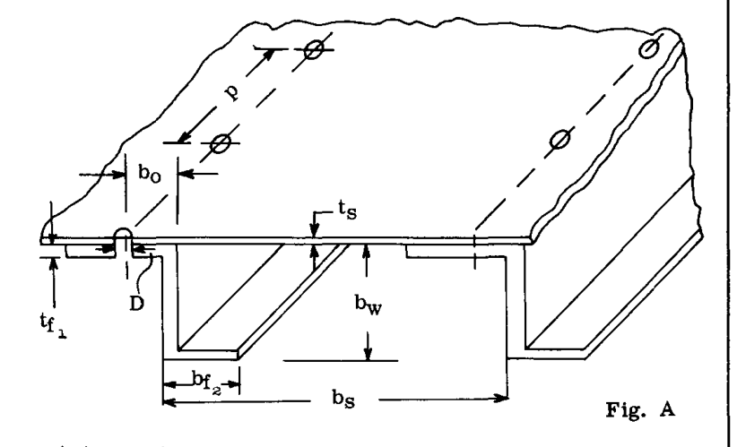

Fig. A

1. $t_f / t_s \ge 0.5$ – 全体的なクリップリングを防止する。
2. $0.4 \le b_f / b_w \le 0.5$ – 横転座屈と局所座屈の防止。
3. $b_o$ をできるだけ小さくする – 面のリンクリングを防止。
4. $p / b_s \le 0.5$ – リベット間座屈を防止。
5. $p / d \le 8$ – 面のリンクリングを防止。
6. リベットまたはスポット溶接の1インチあたりの引張強度は、リンクリングによる破壊を防ぐために $0.05 F_{cy} t_s$ 以上である必要がある。
7. おおよその目安として、面のリンクリングに対する弱さを防ぐために、 $b_s / t_s < 30$ の場合は曲げ加工されたストリンガーを使用しない。

## C7.23 Y字補強外板パネル

Y字形状は板から成形することができないため、押し出し加工する必要がある。Y字形状を効率的にするために、通常、様々な部分で異なる厚さを持っている。さらに、押出材料は、パネルに使用される圧延板と比較して非弾性応力領域で異なる機械的特性を持っているため、補強材および完全なパネルユニットのクリップリング応力を計算する際にこれらの影響を考慮する必要がある。

補強材の有効厚さ $\bar{t}_w$ は、以下の式によって決定される（Ref. 3）。

$$\bar{t}_w = \Sigma \, b_i t_i / \Sigma
\, b_i \quad \text{---} \quad (C7.29)$$

ここで、 $b_i$ および $t_i$ は、それぞれ断面積要素の長さおよび厚さを指す。

補強材と外板の降伏応力 $F_{cy}$ が異なり、有効な $\bar{F}_{cy}$ は以下のように推定できる（Ref. 3）。

$$\bar{F}_{cy} = \left\{ F_{cy(SH)} +
F_{cy(ST)} [(\bar{t}_w/t_s) - 1] \right\} / \bar{t}_w/t_s \quad
\text{---} \quad (C7.30)$$

外板・補強材パネルのモノリシック・クリップリング応力は、式(C7.4)またはFig. C7.7の曲線から計算できる。式(C7.4)は以下の通りである。

$$F_{cs(M)}/F_{cy} = 0.56 \left[ (g t^2 /
A)(E/F_{cy})^{1/2} \right]^{0.85}$$

この式の定数 0.56 は、 $t_w/t_s = 1.0$ の場合のYおよびハット形補強パネルに適用される。他の比率の場合、Gerardの基本式で $\beta_g$ と呼ばれるこの定数の補正は、Fig. C7.30の曲線から得ることができる。

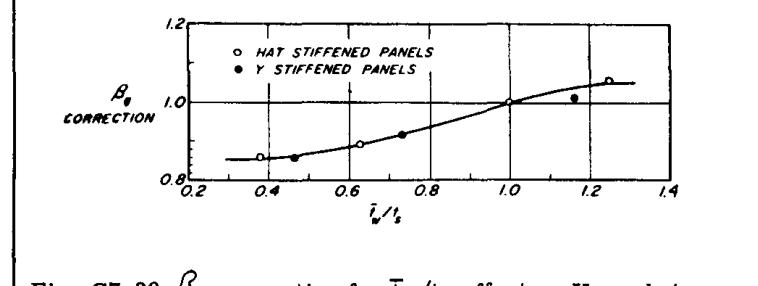

Fig. C7.30